# COMPSCIX 415.2 Homework 6

Claude Phan

3/12/19

My Github repository for my assignments can be found at this URL: https://github.com/claudephan/compscix-415-2-assignments.git

```r
library(mdsr)
library(tidyverse)
library(ggplot2)
library(nycflights13)
library(mosaicData)
```

# Exercise 1

```r
data(Whickham)
?Whickham
```

###### 1. What variables are in this data set?

The dataset contains 3 variables outcome, smoker, and age. Outcome is the survival status after 20 years, a factor with levels Alive or Dead. Smoker is No or Yes. Age is the age in years at the timer of the first survey.

```r
glimpse(Whickham)
```

```
## Observations: 1,314
## Variables: 3
## $ outcome <fct> Alive, Alive, Dead, Alive, Alive, Alive, Alive, Dead, Al…
## $ smoker  <fct> Yes, Yes, Yes, No, No, Yes, Yes, No, No, No, No, Yes, No…
## $ age     <int> 23, 18, 71, 67, 64, 38, 45, 76, 28, 27, 28, 34, 20, 72, …
```

###### 3. Create a table (use the R code below as a guide) and a visualization of the relationship between smoking status and outcome, ignoring age. What do you see? Does it make sense?

We see that the majority of the women are still alive 20 years later and that the majority of the ones that are dead, wer not smokers. This does make sense because 20 years is not a very long time period, especially when you disreguard their current age from the mix.

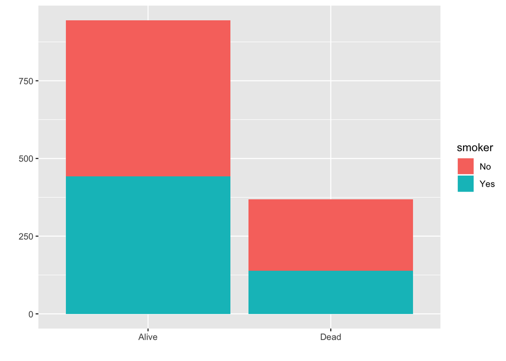

```r
Whickham %>% count( outcome , smoker ) %>% ggplot(aes(x=outcome, y = n)) +
  geom_bar(aes(fill = smoker), stat="identity") +
  xlab("") + ylab("")
```

###### 4. Recode the age variable into an ordered factor with three categories: age <= 44, age > 44 & age <= 64, and age > 64. Now, recreate visualization from above, but facet on your new age factor. What do you see? Does it make sense?

As we can see the older these women get, the less proportion there are thatr died and were smokers. This is expected as there are many ways to die as age begins to settle. However, looking at those under 44, you can see that the ratio looks a bit more even between the smokers and non smokers of those who died. This is also evident by the counts of smokers for those that are alive as well, you can see the propotions are relativlity similair to those dead counterparts.

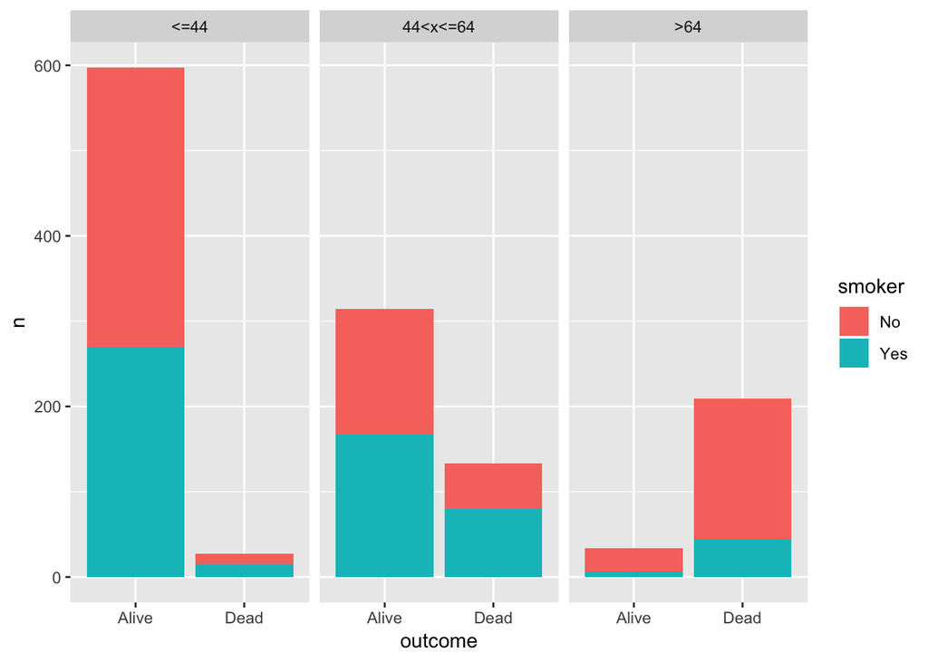

```r
age_cat <- case_when(Whickham$age <= 44 ~ '<=44',
                   Whickham$age > 44 & Whickham$age <= 64 ~ '44<x<=64',
                   Whickham$age > 64 ~ '>64')
age_fct <- factor(age_cat, ordered = TRUE)
age_fct <- fct_relevel(age_fct, '<=44', '44<x<=64', '>64')

age_df <- as.data.frame(age_fct)
df <- merge(Whickham, age_fct, by = "row.names", all = TRUE)

df %>% count( outcome , smoker, y ) %>%
  ggplot(aes(x= outcome, y = n)) +
    geom_bar(aes(fill = smoker), stat="identity") +
    facet_wrap(~ y)
```

# Exercise 2

###### 1. Generate a random sample of size n = 10000 from a gamma(1,2) distribution and plot a histogram or density curve. Use the code below to help you get your sample.

```r
n <- 10000
# look at ?rgamma to read about this function
gamma_samp <- tibble(x = rgamma(n, shape = 1, scale = 2))
```

###### 2. What is the mean and standard deviation of your sample? They should both be close to 2 because for a gamma distribution:

```r
mean_samp <- gamma_samp %>% .[['x']] %>% mean()
mean_samp
```

```
## [1] 2.019462
```

```r
sd_samp <- gamma_samp %>% .[['x']] %>% sd()
sd_samp
```

```
## [1] 2.012804
```

```r
gamma_small <- gamma_samp %>% sample_n(30)

gamma_small  %>%
  summarize(mean_x = mean(x, na.rm = TRUE),
            sd_x = sd(x, na.rm = TRUE))
```

```
## # A tibble: 1 x 2
##   mean_x  sd_x
##    <dbl> <dbl>
## 1   2.64  2.75
```

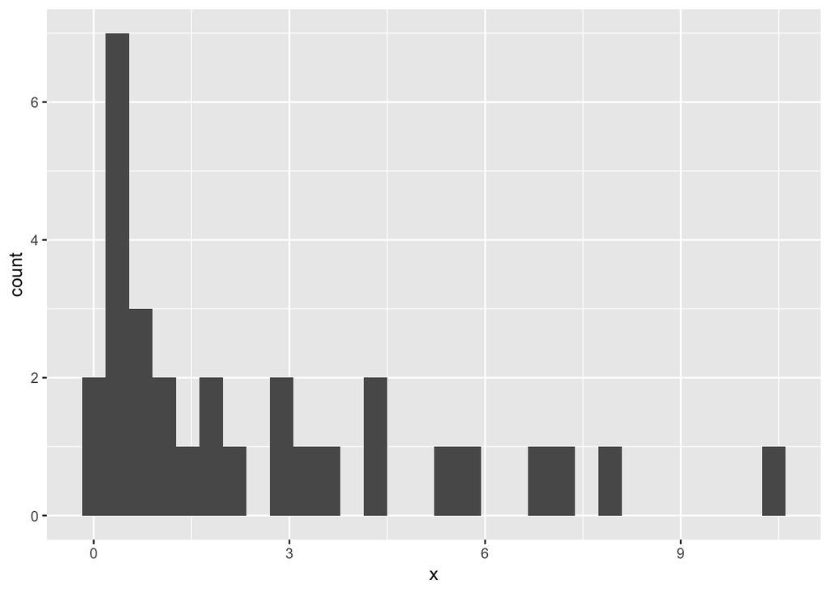

```r
gamma_small %>%
  ggplot(aes(x = x)) +
    geom_histogram()
```

###### 4. Take a sample of size n = 30, again from the Gamma(1,2) distribution, calculate the mean, and assign it to a vector named mean_samp. Repeat this 10000 times!!!!

```r
# create a vector with 10000 NAs
mean_samp <- rep(NA, 10000)
# start a loop
for(i in 1:10000) {
  g_samp <- rgamma(30, shape = 1, scale = 2)
  mean_samp[i] <- mean(g_samp)
}
# Convert vector to a tibble
mean_samp <- tibble(mean_samp)
```

###### 5. Make a histogram of your collection of means from above (mean_samp)

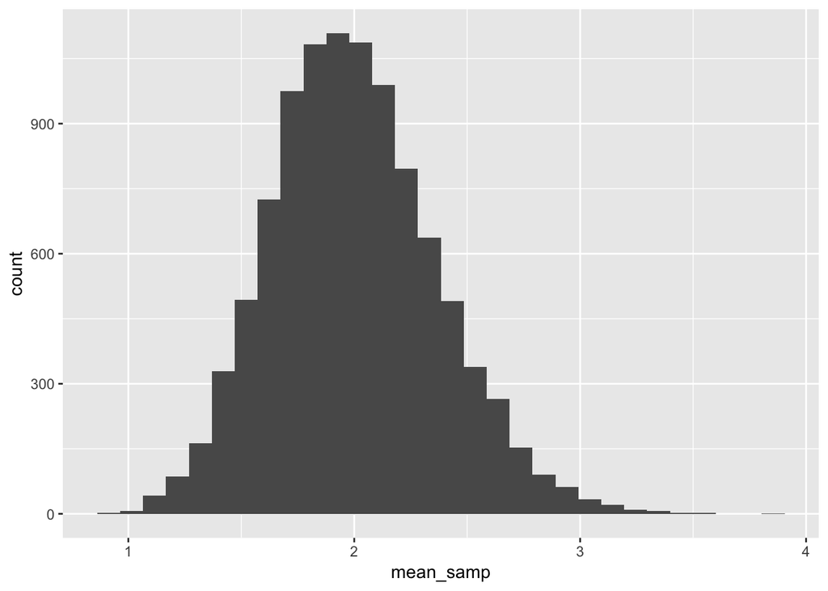

```r
mean_samp %>%
  ggplot(aes(x = mean_samp)) +
    geom_histogram()
```

###### 6. Calculate the mean and standard deviation of all of your sample means

```r
mean_mean_samp <- mean(mean_samp$mean_samp)
sd_mean_samp <- sd(mean_samp$mean_samp)
mean_mean_samp
```

```
## [1] 1.99897
```

```r
sd_mean_samp
```

```
## [1] 0.3655545
```

###### 8. According to the Central Limit Theorem, the mean of your sampling distribution should be very close to 2, and the standard deviation of your sampling distribution should be close to 0.365. Repeat #4-#6, but now with a sample of size n = 300 instead. Do your results match up well with the theorem?

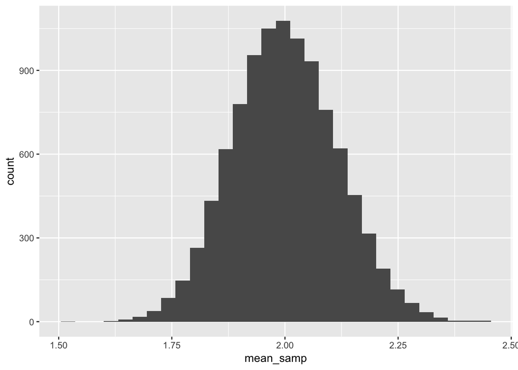

```r
# create a vector with 10000 NAs
mean_samp <- rep(NA, 10000)
# start a loop
for(i in 1:10000) {
  g_samp <- rgamma(300, shape = 1, scale = 2)
  mean_samp[i] <- mean(g_samp)
}
# Convert vector to a tibble
mean_samp <- tibble(mean_samp)

mean_samp %>%
  ggplot(aes(x = mean_samp)) +
    geom_histogram()
```

```r
mean_mean_samp <- mean(mean_samp$mean_samp)
sd_mean_samp <- sd(mean_samp$mean_samp)

mean_mean_samp
```

```
## [1] 2.000233
```

```r
sd_mean_samp
```

```
## [1] 0.1155779
```